# Differential expression analysis of RNA seq read count data

Which genes are differentially expressed between Good vs. Poor cytogenetic risk?

```r
voomCRGP <- topTable(fit, coef = "cytoRiskPoor", p.value = 1e-05, n = Inf)
nrow(voomCRGP)
```

```
## [1] 418
```

```r
head(voomCRGP)
```

```
##                            logFC AveExpr       t   P.Value adj.P.Val     B
## PDE4DIP|9659_calculated   1.6915  5.8688  10.857 2.383e-21 4.767e-17 37.88
## PHKA1|5255_calculated     4.5056  0.9102  10.090 3.521e-19 2.532e-15 32.58
## KRT17|3872_calculated    -4.8819 -0.7307 -10.078 3.798e-19 2.532e-15 32.57
## HOXA6|3203_calculated     5.6839  1.6745   9.792 2.387e-18 1.193e-14 30.97
## ZNF498|221785_calculated -0.7981  5.0916  -9.734 3.468e-18 1.303e-14 30.75
## LPO|4025_calculated      -4.1998  3.9162  -9.691 4.562e-18 1.303e-14 30.46
```

Therefore there are 418 genes are differentially expressed between Good vs. Poor cytogenetic risk.

Plot top 6 genes differentially expressed between Good vs. Poor cytogenetic risk:

```r
voomCRGPgenes <- rownames(voomCRGP)
rDatvoomCR <- rDatCRGIP[head(voomCRGPgenes), ]
dim(rDatvoomCR)
```

```
## [1]   6 176
```

```r
rDatvoomCR$Transcript <- rownames(rDatvoomCR)
rDatvoomCR <- melt(rDatvoomCR, id.vars = "Transcript", variable.name = "TCGA_patient_id",
    value.name = "Read_counts")
rDatvoomCR$Transcript <- gsub("[|].*$", "", rDatvoomCR$Transcript)
head(rDatvoomCR)
```

```
##   Transcript TCGA_patient_id Read_counts
## 1    PDE4DIP            2803       379.0
## 2      PHKA1            2803        10.0
## 3      KRT17            2803       109.5
## 4      HOXA6            2803         6.0
## 5     ZNF498            2803      2425.8
## 6        LPO            2803     11542.2
```

```r
rDatvoomCR <- merge(rDatvoomCR, rDesCRGIP, by = "TCGA_patient_id")
head(rDatvoomCR)
```

```
##   TCGA_patient_id Transcript Read_counts Sex Race FAB_subtype Age
## 1            2803    PDE4DIP       379.0   F    W          M3  61
## 2            2803      PHKA1        10.0   F    W          M3  61
## 3            2803      KRT17       109.5   F    W          M3  61
## 4            2803      HOXA6         6.0   F    W          M3  61
## 5            2803     ZNF498      2425.8   F    W          M3  61
## 6            2803        LPO     11542.2   F    W          M3  61
##   trisomy_8 del_5 del_7 Cytogenetic_risk Molecular_risk
## 1     FALSE FALSE FALSE             Good           Good
## 2     FALSE FALSE FALSE             Good           Good
## 3     FALSE FALSE FALSE             Good           Good
## 4     FALSE FALSE FALSE             Good           Good
## 5     FALSE FALSE FALSE             Good           Good
## 6     FALSE FALSE FALSE             Good           Good
```

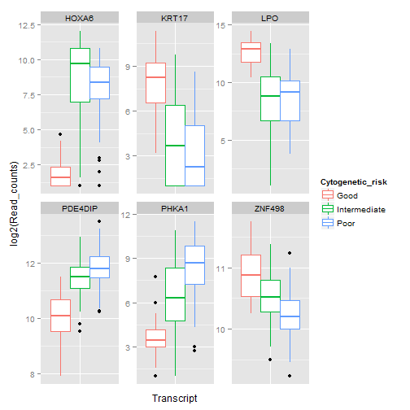

```r
ggplot(rDatvoomCR, aes(Transcript, log2(Read_counts), colour = Cytogenetic_risk)) +
    geom_boxplot() + facet_wrap(~Transcript, scales = "free") + theme(axis.text.x = element_blank(),
    axis.ticks.x = element_blank())
```

Which genes are differentially expressed between Good vs. Intermediate cytogenetic risk?

```r
voomCRGI <- topTable(fit, coef = "cytoRiskIntermediate", p.value = 1e-05, n = Inf)
nrow(voomCRGI)
```

```
## [1] 509
```

```r
head(voomCRGI)
```

```
##                         logFC AveExpr      t   P.Value adj.P.Val     B
## HOXA6|3203_calculated   6.293  1.6745  13.72 1.353e-29 1.912e-25 56.32
## HOXA2|3199_calculated   4.019  0.2094  13.66 1.911e-29 1.912e-25 55.64
## CYP2E1|1571_calculated -3.074  1.5626 -12.86 4.028e-27 2.685e-23 50.58
## HOXA4|3201_calculated   5.449  1.5180  12.79 6.419e-27 3.210e-23 50.13
## HOXA7|3204_calculated   6.657  2.4076  12.13 5.133e-25 2.053e-21 46.02
## LPO|4025_calculated    -4.040  3.9162 -12.02 1.073e-24 3.575e-21 45.47
```

Therefore there are 509 genes differentially expressed between Good vs. Intermediate cytogenetic risk.

Plot top 6 genes differentially expressed between Good vs. Intermediate cytogenetic risk:

```r
voomCRGIgenes <- rownames(voomCRGI)
rDatvoomCR <- rDatCRGIP[head(voomCRGIgenes), ]
dim(rDatvoomCR)
```

```
## [1]   6 176
```

```r
rDatvoomCR$Transcript <- rownames(rDatvoomCR)
rDatvoomCR <- melt(rDatvoomCR, id.vars = "Transcript", variable.name = "TCGA_patient_id",
    value.name = "Read_counts")
rDatvoomCR$Transcript <- gsub("[|].*$", "", rDatvoomCR$Transcript)
head(rDatvoomCR)
```

```
##   Transcript TCGA_patient_id Read_counts
## 1      HOXA6            2803         6.0
## 2      HOXA2            2803         2.0
## 3     CYP2E1            2803       485.7
## 4      HOXA4            2803        10.0
## 5      HOXA7            2803         3.0
## 6        LPO            2803     11542.2
```

```r
rDatvoomCR <- merge(rDatvoomCR, rDesCRGIP, by = "TCGA_patient_id")
head(rDatvoomCR)
```

```
##   TCGA_patient_id Transcript Read_counts Sex Race FAB_subtype Age
## 1            2803      HOXA6         6.0   F    W          M3  61
## 2            2803      HOXA2         2.0   F    W          M3  61
## 3            2803     CYP2E1       485.7   F    W          M3  61
## 4            2803      HOXA4        10.0   F    W          M3  61
## 5            2803      HOXA7         3.0   F    W          M3  61
## 6            2803        LPO     11542.2   F    W          M3  61
##   trisomy_8 del_5 del_7 Cytogenetic_risk Molecular_risk
## 1     FALSE FALSE FALSE             Good           Good
## 2     FALSE FALSE FALSE             Good           Good
## 3     FALSE FALSE FALSE             Good           Good
## 4     FALSE FALSE FALSE             Good           Good
## 5     FALSE FALSE FALSE             Good           Good
## 6     FALSE FALSE FALSE             Good           Good
```

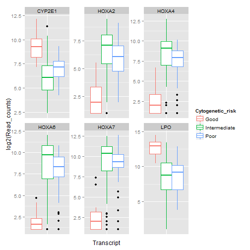

```r
ggplot(rDatvoomCR, aes(Transcript, log2(Read_counts), colour = Cytogenetic_risk)) +
    geom_boxplot() + facet_wrap(~Transcript, scales = "free") + theme(axis.text.x = element_blank(),
    axis.ticks.x = element_blank())
```

How can we compare Intermediate and Poor risk? Create a contrast matrix:

```r
colnames(design)
```

```
## [1] "(Intercept)"          "cytoRiskIntermediate" "cytoRiskPoor"
```

```r
(contMatrix <- makeContrasts(PoorVsInt = cytoRiskPoor - cytoRiskIntermediate,
    levels = design))
```

```
##                       Contrasts
## Levels                 PoorVsInt
##   Intercept                    0
##   cytoRiskIntermediate        -1
##   cytoRiskPoor                 1
```

```r
fitCont <- contrasts.fit(fit, contMatrix)
EbFitCont <- eBayes(fitCont)
voomCRIP <- topTable(EbFitCont, p.value = 1e-05, n = Inf)
nrow(voomCRIP)
```

```
## [1] 148
```

```r
head(voomCRIP)
```

```
##                             logFC AveExpr      t   P.Value adj.P.Val     B
## HOXB8|3218_calculated     -2.9149  -2.026 -9.157 1.336e-16 2.409e-12 26.94
## ZNF560|147741_calculated   2.6197  -2.885  9.063 2.409e-16 2.409e-12 25.93
## PDAP1|11333_calculated    -0.5178   5.596 -8.655 3.024e-15 1.780e-11 24.12
## SLC25A13|10165_calculated -0.6546   4.608 -8.629 3.559e-15 1.780e-11 23.90
## HOXB7|3217_calculated     -2.5818  -1.043 -8.522 6.857e-15 2.743e-11 22.90
## SLC18A2|6571_calculated    2.5094   2.453  8.291 2.796e-14 9.320e-11 21.68
```

```r
resCont <- decideTests(EbFitCont, p.value = 1e-05, method = "global")
summary(resCont)
```

```
##    PoorVsInt
## -1       103
## 0      19853
## 1         45
```

```r
# negHits <- rownames(rDatCRGIP)[which(resCont[ , 'PoorVsInt'] < 0)] posHits
# <- rownames(rDatCRGIP)[which(resCont[ , 'PoorVsInt'] > 0)]
```

Therefore there are 148 genes differentially expressed between Intermediate and Poor cytogenetic risk.

Plot top 6 genes differentially expressed between Intermediate and Poor cytogenetic risk:

```r
voomCRIPgenes <- rownames(voomCRIP)
rDatvoomCR <- rDatCRGIP[head(voomCRIPgenes), ]
dim(rDatvoomCR)
```

```
## [1]   6 176
```

```r
rDatvoomCR$Transcript <- rownames(rDatvoomCR)
rDatvoomCR <- melt(rDatvoomCR, id.vars = "Transcript", variable.name = "TCGA_patient_id",
    value.name = "Read_counts")
rDatvoomCR$Transcript <- gsub("[|].*$", "", rDatvoomCR$Transcript)
head(rDatvoomCR)
```

```
##   Transcript TCGA_patient_id Read_counts
## 1      HOXB8            2803         4.0
## 2     ZNF560            2803         2.0
## 3      PDAP1            2803      2211.5
## 4   SLC25A13            2803       934.7
## 5      HOXB7            2803        20.0
## 6    SLC18A2            2803       659.2
```

```r
rDatvoomCR <- merge(rDatvoomCR, rDesCRGIP, by = "TCGA_patient_id")
head(rDatvoomCR)
```

```
##   TCGA_patient_id Transcript Read_counts Sex Race FAB_subtype Age
## 1            2803      HOXB8         4.0   F    W          M3  61
## 2            2803     ZNF560         2.0   F    W          M3  61
## 3            2803      PDAP1      2211.5   F    W          M3  61
## 4            2803   SLC25A13       934.7   F    W          M3  61
## 5            2803      HOXB7        20.0   F    W          M3  61
## 6            2803    SLC18A2       659.2   F    W          M3  61
##   trisomy_8 del_5 del_7 Cytogenetic_risk Molecular_risk
## 1     FALSE FALSE FALSE             Good           Good
## 2     FALSE FALSE FALSE             Good           Good
## 3     FALSE FALSE FALSE             Good           Good
## 4     FALSE FALSE FALSE             Good           Good
## 5     FALSE FALSE FALSE             Good           Good
## 6     FALSE FALSE FALSE             Good           Good
```

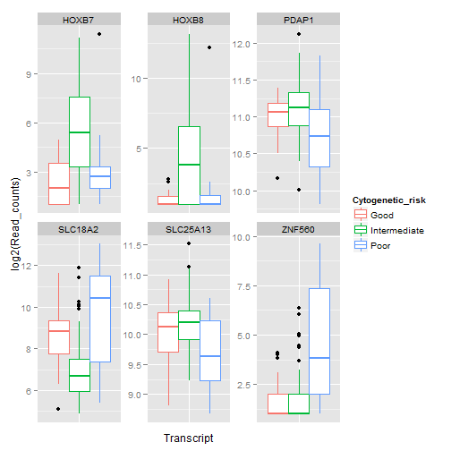

```r
ggplot(rDatvoomCR, aes(Transcript, log2(Read_counts), colour = Cytogenetic_risk)) +
    geom_boxplot() + facet_wrap(~Transcript, scales = "free") + theme(axis.text.x = element_blank(),
    axis.ticks.x = element_blank())
```

Create a Venn diagram to show which genes were differentially expressed:

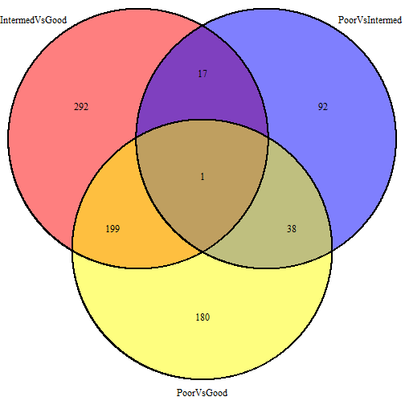

```r
deGenes <- list(IntermedVsGood = voomCRGIgenes, PoorVsIntermed = voomCRIPgenes,
    PoorVsGood = voomCRGPgenes)
plot.new()
vennPlot <- venn.diagram(deGenes, filename = NULL, force.unique = TRUE, fill = c("red",
    "blue", "yellow"))
grid.draw(vennPlot)
```

Wow one gene is differentially expressed between all groups? What is it?!

```r
(luckyGene <- (intersect(intersect(voomCRGIgenes, voomCRIPgenes), voomCRGPgenes)))
```

```
## [1] "ZNF498|221785_calculated"
```

It is a zinc finger protein on chromosome 7, which we know is commonly deleted in AML! Nice. Let's check its expression!

```r
rDatvoomCR <- rDatCRGIP[head(luckyGene), ]
rDatvoomCR$Transcript <- rownames(rDatvoomCR)
rDatvoomCR <- melt(rDatvoomCR, id.vars = "Transcript", variable.name = "TCGA_patient_id",
    value.name = "Read_counts")
rDatvoomCR$Transcript <- gsub("[|].*$", "", rDatvoomCR$Transcript)
head(rDatvoomCR)
```

```
##   Transcript TCGA_patient_id Read_counts
## 1     ZNF498            2803        2426
## 2     ZNF498            2805        1488
## 3     ZNF498            2806        2371
## 4     ZNF498            2807        1555
## 5     ZNF498            2808        1543
## 6     ZNF498            2811        1632
```

```r
rDatvoomCR <- merge(rDatvoomCR, rDesCRGIP, by = "TCGA_patient_id")
head(rDatvoomCR)
```

```
##   TCGA_patient_id Transcript Read_counts Sex Race FAB_subtype Age
## 1            2803     ZNF498        2426   F    W          M3  61
## 2            2805     ZNF498        1488   M    W          M0  77
## 3            2806     ZNF498        2371   M    W          M1  46
## 4            2807     ZNF498        1555   F    W          M1  68
## 5            2808     ZNF498        1543   M    W          M2  23
## 6            2811     ZNF498        1632   M    W          M4  81
##   trisomy_8 del_5 del_7 Cytogenetic_risk Molecular_risk
## 1     FALSE FALSE FALSE             Good           Good
## 2     FALSE FALSE FALSE     Intermediate   Intermediate
## 3     FALSE FALSE FALSE             Good           Good
## 4     FALSE FALSE FALSE     Intermediate   Intermediate
## 5     FALSE FALSE FALSE     Intermediate   Intermediate
## 6     FALSE FALSE FALSE     Intermediate   Intermediate
```

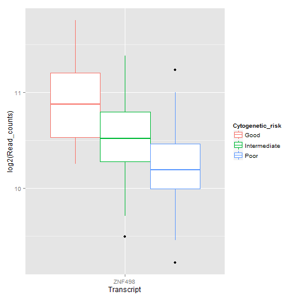

```r
ggplot(rDatvoomCR, aes(Transcript, log2(Read_counts), colour = Cytogenetic_risk)) +
    geom_boxplot()
```